# Exam 2008 problem 3

### 02409 Multivariate Statistics

`Week J`

For several of the following questions we will be referring to the following models:

“Model M1”: is a regression model based on all 45 observations which might be written as:

$$\begin{bmatrix} 676\\ 516 \\ \vdots \\ 1560 \end{bmatrix} =
\begin{bmatrix} 1 & 5.00 & 35184.5 \\ 1 & 4.75 & 28170.4
\\ & \vdots & \\ 1 & 5.40 & 16892.2 \end{bmatrix}
\begin{bmatrix} \alpha \\ \beta_1 \\ \beta_2 \end{bmatrix} +
\begin{bmatrix} \epsilon_1 \\ \epsilon_2 \\ \vdots \\ \epsilon_{45}
\end{bmatrix}$$

The residuals are assumed identically, independently, and normally distributed.

“Model M2”: is a regression model based on all 45 observations which might be written as:
$$\begin{bmatrix} 676\\ 516 \\ \vdots \\ 1560 \end{bmatrix} = \mu +
\begin{bmatrix} \epsilon_1 \\ \epsilon_2 \\ \vdots \\ \epsilon_{45}
\end{bmatrix}$$

The residuals are assumed identically, independently, and normally distributed.

```r
LSA <- data.frame("Location" = c("OI","OI","OI","OI","OI","OI","OI","OI","OI","OI","OI","OI","OI","OI","OI","SI","SI","SI","SI","SI","SI","SI","SI","SI","SI","SI","SI","SI","SI","SI","SM","SM","SM","SM","SM","SM","SM","SM","SM","SM","SM","SM","SM","SM","SM"),
                  "Type" = c("DVEG","DVEG","DVEG","DVEG","DVEG","SHRT","SHRT","SHRT","SHRT","SHRT","TALL","TALL","TALL","TALL","TALL","DVEG","DVEG","DVEG","DVEG","DVEG","SHRT","SHRT","SHRT","SHRT","SHRT","TALL","TALL","TALL","TALL","TALL","DVEG","DVEG","DVEG","DVEG","DVEG","SHRT","SHRT","SHRT","SHRT","SHRT","TALL","TALL","TALL","TALL","TALL"),
                  "Biomass" = c(676,516,1052,868,1008,436,544,680,640,492,984,1400,1276,1736,1004,396,352,328,392,236,392,268,252,236,340,2436,2216,2096,1660,2272,824,1196,1960,2080,1764,412,416,504,492,636,1756,1232,1400,1620,1560),
                  "Salinity" = c(33,35,32,30,33,33,36,30,38,30,30,37,33,36,30,30,27,29,34,36,30,28,31,31,35,29,35,35,30,30,26,29,25,26,26,25,26,26,27,27,24,27,26,28,28),
                  "pH" = c(5.00,4.75,4.20,4.40,5.55,5.05,4.25,4.45,4.75,4.60,4.10,3.45,3.45,4.10,3.50,3.25,3.35,3.20,3.35,3.30,3.25,3.25,3.20,3.20,3.35,7.10,7.35,7.45,7.45,7.40,4.85,4.60,5.20,4.75,5.20,4.55,3.95,3.70,3.75,4.15,5.60,5.35,5.50,5.50,5.40),
                  "K" = c(1441.67,1299.19,1154.27,1045.15,521.62,1273.02,1346.35,1253.88,1242.65,1281.95,553.69,494.74,525.97,571.14,408.64,646.65,14.03,350.73,496.29,580.92,535.82,490.34,552.39,661.32,672.15,528.65,563.13,497.96,458.38,498.25,936.26,894.79,941.36,1038.79,898.05,989.87,951.28,939.83,925.42,954.11,720.72,782.09,773.30,829.26,856.96),
                  "Na" = c(35184.5,28170.4,26455.0,25072.9,31664.2,25491.7,20877.3,25621.3,27587.3,26511.7,7886.5,14596.0,9826.8,11978.4,10368.6,17307.4,12822.0,8582.6,12369.5,14731.9,15060.6,11056.3,8118.9,13009.5,15003.7,10225.0,8024.2,10393.0,8711.6,10239.6,20436.0,12519.9,18979.0,22986.1,11704.5,17721.0,16485.2,17101.3,17849.0,16949.6,11344.6,14752.4,13649.8,14533.0,16892.2),
                  "Zn" = c(16.4524,13.9852,15.3276,17.3128,22.3312,12.2778,17.8225,14.3516,13.6826,11.7566,9.8820,16.6752,12.3730,9.4058,14.9302,31.2865,30.1652,28.5901,19.8795,18.5056,22.1344,28.6101,23.1908,24.6917,22.6758,0.3729,0.2703,0.3205,0.2648,0.2105,18.9875,20.9687,23.9841,19.9727,21.3864,23.7063,30.5589,26.8415,27.7292,21.5699,19.6531,20.3295,19.5880,20.1328,19.2420))
```

## Question 3.1.

Using maximum likelihood $\alpha$ in model $M_1$ is estimated at:

1. $-475.73$
2. $404.95$
3. $-0.02333$
4. $0.0893$
5. $0.0101$
6. $\text{Don't know.}$

## Question 3.2.

The reduction in variance when going from model $M_2$ to model $M_1$ amounts to the following fraction:

1. $1.0$
2. $0.6584$
3. $40.48$
4. $394.85$
5. $45$
6. $\text{Don't know.}$

## Question 3.3.

For model $M_1$ the usual (formal) test statistic for the hypothesis: “$R^2 = 0$” has the value:

1. $40.48$
2. $-1.74 + 8.48 - 2.70$
3. $0.6584$
4. $394.85$
5. $39.45$
6. $\text{Don't know.}$

## Question 3.4

Consider model $M_1$. Under the null-hypothesis “$R^2 = 0$” the usual (formal) test statistic is distributed as:

1. $\text{F(42,44)}$
2. $\text{F(3,44)}$
3. $\text{F(3,42)}$
4. $\text{F(2,44)}$
5. $\text{F(2,42)}$
6. $\text{Don't know.}$

## Question 3.5.

Using model $M_1$ the first observation is predicted at:

1. $728.30$
2. $-475.72$
3. $394.85$
4. $404.94$
5. $-52.30$
6. $\text{Don't know.}$

## Question 3.6.

Values of Cook’s D for model $M_1$ can be compared to a suitable percentile in the following distribution:

1. $\text{F(1,44)}$
2. $\text{F(2,43)}$
3. $\text{F(3,42)}$
4. $\text{F(4,41)}$
5. $\text{F(5,40)}$
6. $\text{Don't know.}$

## Question 3.7.

$\text{RSTUDENT}_{34}$ (corresponding to observation 34) for model $M_1$ is estimated at:

1. $1168$
2. $\frac{1168}{394.85}$
3. $\frac{1168}{353.47}$
4. $\frac{1168}{394.85\sqrt{1-0.0423}}$
5. $\frac{1168}{353.47\sqrt{1-0.0423}}$
6. $\text{Don't know.}$

## Question 3.8.

In order to calculate a 95% prediction interval for model $M_1$ we need a suitable percentile in a t-distribution. The value we need is:

1. $1.68 \text{(approximately)}$
2. $2.02 \text{(approximately)}$
3. $2.92 \text{(approximately)}$
4. $3.18 \text{(approximately)}$
5. $4.30 \text{(approximately)}$
6. $\text{Don't know.}$

## Question 3.9.

A general linear model “Model $M_3$” based on all 45 observations with separate intercepts for the three localities might be written as:

$$\begin{bmatrix} 676\\ 516 \\ \vdots \\ 352 \\ \vdots \\ 1560
\end{bmatrix} = \begin{bmatrix} 1 & 0 & 0 & 5.00 &
35184.5 \\ 1 & 0 & 0 & 4.75 & 28170.4 \\ & &
\vdots & & \\ 0 & 1 & 0 & 3.35 & 12822.0 \\
& & \vdots & & \\ 0 & 0 & 1 & 5.40 &
16892.2 \end{bmatrix} \begin{bmatrix} ^{\alpha}\text{OI} \\
^{\alpha}\text{SI} \\ ^{\alpha}\text{SM} \\ \gamma_1 \\ \gamma_2
\end{bmatrix} +
\begin{bmatrix} \omega_1 \\ \omega_2 \\ \vdots \\ \omega_{17} \\ \vdots
\\ \omega_{45} \end{bmatrix}$$

The residuals are assumed identically, independently, and normally distributed.

An ANOVA table for this model is:

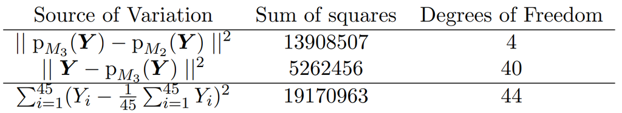

The usual test statistic for testing if there is a difference in intercept between the three locations is found as:

1. $\large{\frac{(13908507 - 5262456)/2}{19170963/44}}$
2. $\large{\frac{(13908507 - 6548174)/2}{5262456/42}}$
3. $\large{\frac{(13908507 - 12622789)/2}{19170963/44}}$
4. $\large{\frac{(13908507 - 12622789)/1}{5262456/40}}$
5. $\large{\frac{(13908507 - 12622789)/2}{5262456/40}}$
6. $\text{Don't know.}$